# The Normal Distribution

P. Lombardo

## Loading packages and data

```r
library(tidyverse)
library(patchwork)
set.seed(234)
bank<-data.frame(savings = round(rnorm(1000,2100,150),2))
source('source_files/general.R')
source('source_files/normal_1.R')
```

## Modeling Sampling Distributions

In our last lesson, we learned about sampling distributions for a statistic and discovered that they reveal three important “aggregate behaviors” for statistics generated from random samples. However, there is still one pretty glaring shortcoming of this process:

> Any situation where we could generate a sampling distribution to understand the “aggregate behavior” would require us knowing the all the population information in the first place. So…

Yes. That is a problem. So, practically speaking, generating a sampling distribution won’t work for us.

*Luckily for us*, there is a beautiful theorem from probability that essentially gives us access to decent models for common sampling distributions: *The Central Limit Theorem.* But before we can talk about that, we need to learn about *The Normal Distribution* and how it works as a probability model.

## Probability Models

*Caveat:* My treatment of probability and random variables here is more intuitive than it is formal. I’m trying to emphasize ways to *think* about these things, rather that shooting for mathematical accuracy and precision.

We will think of a *probability model* as a tool that makes predictions.

- We will consider a model **good** if the probability it reports matches with the relative frequency of an measurement after collecting a lot of data.
- With **bad** model, this probability prediction is quite different from the relative frequencies we get from collecting a lot of data.

Remember the example from the reading. If a coin is a fair coin, then a *good* probability model would involve one that predicts the probability of heads is 0.5 and the same for tails. We can verify if this is a good model by flipping a coin 10,000 times and looking at the relative frequency of heads.

### The Normal Distribution

This is a *continuous probability model*, so here’s the scoop:

> Basic idea:
> - the space is a continuous interval ($x$-axis), and
> - Area Under Curve == Probabilities.

The normal distribution predicts the probability that measurement ($X$) will fall in a certain region of the $x$-axis. For example, the probability a measurement $X$ will be less than or equal to 3: $P(X\leq3)$.

For the normal distributions, we also know:

- its “bell-shaped” and symmetric;
- we can control the location of the peak by adjusting the $\mu$ parameter;
- we can adjust how “spread out” the probabilities are using the $\sigma$ parameter.

Let’s look at this visually first with a [Shiny App](https://stem.endicott.edu/pl-shiny/probability-distributions/norm-distr-explore/).

### Application to savings accounts

The `bank` data frame contains the amounts in the **savings** accounts for a large collection of people. Let’s explore how a “good” normal probability model can make predictions about relative frequencies.

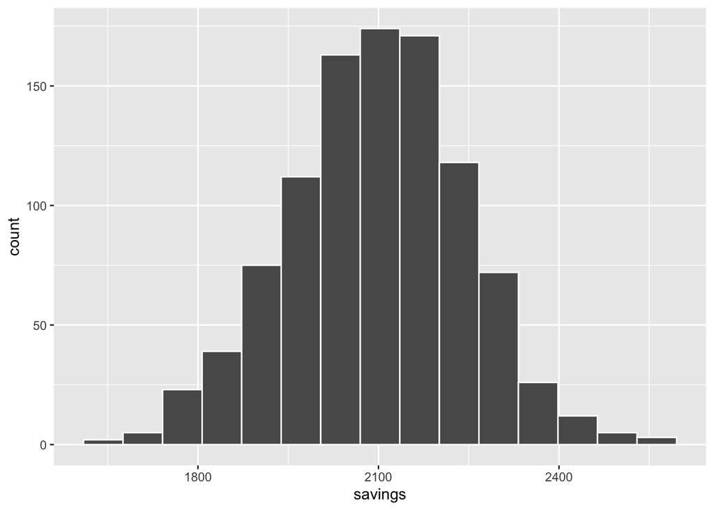

```r
ggplot(data = bank,
       aes(x = savings))+
    geom_histogram(bins = 15, color='white')
```

Let $X$ represent a measurement, so the amount in the savings account of a person at the bank. Use a normal distribution to model $X$, and assume it has parameters $\mu = 2100$ and $\sigma = 150$.

```r
# Relative frequency:
sum(bank$savings <= 1900)/nrow(bank)
```

```
## [1] 0.098
```

```r
# Probability?
# Yes, R has a function for that: pnorm()
pnorm(1900, 2100, 150)
```

```
## [1] 0.09121122
```

1. *How did they compare? Is our normal distribution a “good model”?*

These values are quite close, so it seems like this would be a good probability model. (Tecnicially, you’d want to check more than just one probability/rel-frequency pair; maybe try X <= 2200.)

[figure not shown]

```r
cplot
```

```r
# label below should say "Good" normal probability model
```

So rather than using the histogram bars to determine a relative frequency, we can just compute area under the normal probability curve:

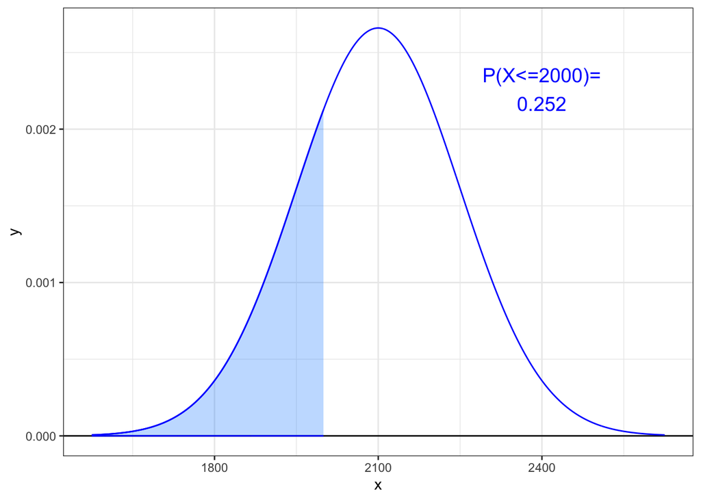

```r
norm_vis(2000, mu = 2100, sigma = 150, tail="lower")
```

#### A bad model

Now consider a normal random variable model where $\mu = 2200$ and $\sigma = 200$.

- Once again, compare $P(X\leq 2000)$ with the relative frequency of people with **savings** balances less than $2,000.

```r
# Relative frequency:
sum(bank$savings <= 2000)/nrow(bank)
```

```
## [1] 0.249
```

```r
# Probability?
# Remember to update your parameters for pnorm so mu = 2200 and sigma = 200
pnorm(2000, 2200, 200)
```

```
## [1] 0.1586553
```

How does it look?

[figure not shown]

```r
cplot_bad
```

## Using `pnorm()` to compute probabilities

For statistics, we typically care about computing three “types” of probabilities.

1. $P(X\leq a)$ (a lower tail): Here, `pnorm()` is already set up to work for us. We simply use `pnorm(a, mu, sigma)`, where `mu` and `sigma` are the parameters we chose for our model.
2. $P(X\geq a)$ (an upper tail): Since `pnorm()` only computes “less than” probabilities; we have to use use an equality I call the “one minus trick”:
   $$P(X\geq a) = 1 - P(X\leq a).$$
   Hence, for “greater than” probabilities, we use `1 - pnorm(a, mu, sigma)`.
3. $P(a \leq X \leq b)$ (a “middle area”): A similar argument as above leads us to the “big minus little trick:
   $$P(a\leq X \leq b) = P(X\leq
   b) - P(X\leq a).$$
   Hence, for”middle area” probabilities, we use `pnorm(b,mu,sigma) - pnorm(a,mu,sigma)`.

Let’s practice our probability computations while verifying that a normal distribution is a good model for the savings account values. Remember our “good” parameters were $\mu = 2100$ and $\sigma = 150$.

**Exercise 1.** Find the rel. frequency of accounts with savings that are between $2,000 and $2,300. Then, compute the analogous probability using our assumed normal r.v. model.

```r
# rel. frequency
# 1. count how many have between 2000 and 2300 in their accounts.
# (how many <= 2300)  - (how many <= 2000)
middle <- sum(bank$savings <=2300) - sum(bank$savings <=2000)
middle/nrow(bank)
```

```
## [1] 0.668
```

```r
# probability using the normal rv model
pnorm(2300, 2100, 150) - pnorm(2000, 2100, 150)
```

```
## [1] 0.6562962
```

**Exercise 2.** Find the rel. frequency of savings accounts with more than $2,250. Then, compute the analogous probability using our assumed normal r.v. model.

```r
# rel. frequency
# 1 - percentage that are <= 2250
1 - sum(bank$savings <= 2250)/nrow(bank)
```

```
## [1] 0.153
```

```r
# probability using the normal rv model
1 - pnorm(2250, 2100, 150)
```

```
## [1] 0.1586553
```

**Main Idea:** Assuming you get get parameters that lead to a “good model”…

- *how well did the normal model do at “predicting” the rel. frequencies in our sampling distribution?*

It does pretty well. In fact, the differences we do see in the prediction from the “good” normal model and the relative frequencies are likely because we only have 1,000 observations in the data. These would get closer with more data, most likely.

- What did you notice in the comparisons between probabilities and rel. frequencies above?

The probabilities coming from our normal distribution model are quite close the the rel. frequencies we observe in our data.

## Summary!

Here’s the big idea. If data has a normal shape, then with the right choice of parameters for `mu` and `sigma` we can use a *normal random variable* to effectively replace having the data set. This may be beneficial because:

- The normal distribution is a theoretical construct; it does not require any arduous sampling loops, computational strength, or **even access to data**!
- The probabilities coming from our normal distribution model can give us pretty accurate estimates of important information about the underlying data it models. Specifically:
  - `mu` is essentially the mean of the data;
  - `sigma` is essentially the standard deviation of the data;
  - the *percentiles* of the data correspond to the percentiles of the normal distribution; and
  - the rel. frequencies of data falling in a certain region correspond to the probability of the same region for our normal random variable.

So how will we use all this?

> The Central Limit Theorem shows that under certain assumptions, the sampling distributions for means and percentages have a normal distribution. Moreover, *it provides formulas for the $\mu$ and $\sigma$ parameters!*

This means rather than generating a sampling distribution, we can just apply the Central Limit Theorem to glean the “aggregate” information we need about the sampling distribution.